# LUAD

Cihan

27 12 2021

#LIBRARIES We first load necessary libraries

```r
#install.packages("naniar")
#install.packages("superml")
library(naniar)
```

```r
library(ggplot2)
library(dplyr)
library(tidyverse)
library(corrplot)
library(superml) #Label Encoding
library(caret) #dummyVars for One Hot Encoding
```

# DATA

### Load the Data

```r
missing.values <- c("N/A","na","?","", "NaN", "not reported", "NA")

#data <- read.csv("C:\\Users\\sakma\\Desktop\\Ders Kayıtları\\Data Mining\\Final Project\\TCGA-LUAD_clinical.csv", na.strings=missing.values)

data <- read.csv("C:\\Users\\Gaye\\OneDrive\\Masaüstü\\dersKayıtü\\DataScience\\DataScienceFinal\\TCGA-LUAD_clinical.csv", na.strings=missing.values)
```

### **We should give some information about data….**

```r
summary(data)
```

```
##  submitter_id       classification_of_tumor last_known_disease_status
##  Length:522         Mode:logical            Mode:logical
##  Class :character   NA's:522                NA's:522
##  Mode  :character
##
##
##
##
##  updated_datetime   primary_diagnosis  tumor_stage        age_at_diagnosis
##  Length:522         Length:522         Length:522         Min.   :12179
##  Class :character   Class :character   Class :character   1st Qu.:21731
##  Mode  :character   Mode  :character   Mode  :character   Median :24411
##                                                           Mean   :24015
##                                                           3rd Qu.:26630
##                                                           Max.   :32432
##                                                           NA's   :31
##  vital_status        morphology        days_to_death
##  Length:522         Length:522         Min.   :   0.0
##  Class :character   Class :character   1st Qu.: 297.8
##  Mode  :character   Mode  :character   Median : 619.0
##                                        Mean   : 791.4
##                                        3rd Qu.:1120.0
##                                        Max.   :4961.0
##                                        NA's   :338
##  days_to_last_known_disease_status created_datetime    state
##  Mode:logical                      Mode:logical     Length:522
##  NA's:522                          NA's:522         Class :character
##                                                     Mode  :character
##
##
##
##
##  days_to_recurrence diagnosis_id       tumor_grade    tissue_or_organ_of_origin
##  Mode:logical       Length:522         Mode:logical   Length:522
##  NA's:522           Class :character   NA's:522       Class :character
##                     Mode  :character                  Mode  :character
##
##
##
##
```

[output cut: 41 more lines]

```
##  Min.   :1993   Length:522         Mode:logical       Mode:logical
##  1st Qu.:2004   Class :character   NA's:522           NA's:522
##  Median :2007   Mode  :character
##  Mean   :2006
##  3rd Qu.:2009
##  Max.   :2013
##  NA's   :399
##  treatment_or_therapy bcr_patient_barcode   disease
##  Mode:logical         Length:522          Length:522
##  NA's:522             Class :character    Class :character
##                       Mode  :character    Mode  :character
##
##
##
##
```

```r
str(data) #Types of features
```

```
## 'data.frame':    522 obs. of  42 variables:
##  $ submitter_id                     : chr  "TCGA-05-4244" "TCGA-05-4245" "TCGA-05-4249" "TCGA-05-4250" ...
##  $ classification_of_tumor          : logi  NA NA NA NA NA NA ...
##  $ last_known_disease_status        : logi  NA NA NA NA NA NA ...
##  $ updated_datetime                 : chr  "2018-09-06T21:10:41.393019-05:00" "2018-09-06T21:10:41.393019-05:00" "2018-09-06T21:10:41.393019-05:00" "2018-09-06T21:10:41.393019-05:00" ...
##  $ primary_diagnosis                : chr  "Adenocarcinoma, NOS" "Adenocarcinoma, NOS" "Adenocarcinoma, NOS" "Adenocarcinoma, NOS" ...
##  $ tumor_stage                      : chr  "stage iv" "stage iiia" "stage ib" "stage iiia" ...
##  $ age_at_diagnosis                 : int  25752 29647 24532 29068 24868 24411 25660 21430 27971 28094 ...
##  $ vital_status                     : chr  "alive" "alive" "alive" "dead" ...
##  $ morphology                       : chr  "8140/3" "8140/3" "8140/3" "8140/3" ...
##  $ days_to_death                    : int  NA NA NA 121 NA NA NA NA 0 303 ...
##  $ days_to_last_known_disease_status: logi  NA NA NA NA NA NA ...
##  $ created_datetime                 : logi  NA NA NA NA NA NA ...
##  $ state                            : chr  "released" "released" "released" "released" ...
##  $ days_to_recurrence               : logi  NA NA NA NA NA NA ...
```

[output cut: 28 more lines]

# PREPROCESSING

## First we’re going to drop the fully NaN columns. Because these columns are not useful for us.

Maybe we can show these fully nan columns in a fashionable way.

**we are going to get a rough glimpse on the missingness situation with the pretty neat naniar package**

**Note:** we can go through https://towardsdatascience.com/smart-handling-of-missing-data-in-r-6425f8a559f2 and leave some comments for our dataset.

```r
# Are there missing values in the dataset?
any_na(data)
```

```
## [1] TRUE
```

```r
# How many?
n_miss(data)
```

```
## [1] 9992
```

```r
prop_miss(data)
```

```
## [1] 0.4557562
```

```r
# Which variables are affected?
data %>% is.na() %>% colSums()
```

```
##                      submitter_id           classification_of_tumor
##                                 0                               522
##         last_known_disease_status                  updated_datetime
##                               522                                 0
##                 primary_diagnosis                       tumor_stage
##                                 0                                 8
##                  age_at_diagnosis                      vital_status
##                                31                                 0
##                        morphology                     days_to_death
##                                 0                               338
## days_to_last_known_disease_status                  created_datetime
##                               522                               522
##                             state                days_to_recurrence
##                                 0                               522
##                      diagnosis_id                       tumor_grade
##                                 0                               522
##         tissue_or_organ_of_origin                     days_to_birth
##                                 0                                31
##         progression_or_recurrence                  prior_malignancy
##                               522                               522
##       site_of_resection_or_biopsy            days_to_last_follow_up
##                                 0                               127
##                cigarettes_per_day                            weight
##                               166                               522
##                   alcohol_history                 alcohol_intensity
##                               522                               522
##                               bmi                      years_smoked
##                               522                               328
##                       exposure_id                            height
##                                 0                               522
##                            gender                     year_of_birth
##                                 0                                19
##                              race                    demographic_id
##                                67                                 0
##                         ethnicity                     year_of_death
##                               126                               399
##                      treatment_id                therapeutic_agents
##                                 0                               522
##             treatment_intent_type              treatment_or_therapy
##                               522                               522
##               bcr_patient_barcode                           disease
##                                 0                                 0
```

```r
data_new <- data[ , colSums(is.na(data)) < nrow(data)]
summary(data_new)
```

```
##  submitter_id       updated_datetime   primary_diagnosis  tumor_stage
##  Length:522         Length:522         Length:522         Length:522
##  Class :character   Class :character   Class :character   Class :character
##  Mode  :character   Mode  :character   Mode  :character   Mode  :character
##
##
##
##
##  age_at_diagnosis vital_status        morphology        days_to_death
##  Min.   :12179    Length:522         Length:522         Min.   :   0.0
##  1st Qu.:21731    Class :character   Class :character   1st Qu.: 297.8
##  Median :24411    Mode  :character   Mode  :character   Median : 619.0
##  Mean   :24015                                          Mean   : 791.4
##  3rd Qu.:26630                                          3rd Qu.:1120.0
##  Max.   :32432                                          Max.   :4961.0
##  NA's   :31                                             NA's   :338
##     state           diagnosis_id       tissue_or_organ_of_origin
##  Length:522         Length:522         Length:522
##  Class :character   Class :character   Class :character
##  Mode  :character   Mode  :character   Mode  :character
##
##
##
##
##  days_to_birth    site_of_resection_or_biopsy days_to_last_follow_up
##  Min.   :-32432   Length:522                  Min.   :   0.0
##  1st Qu.:-26630   Class :character            1st Qu.: 365.5
##  Median :-24411   Mode  :character            Median : 624.0
##  Mean   :-24015                               Mean   : 867.8
##  3rd Qu.:-21731                               3rd Qu.:1065.5
##  Max.   :-12179                               Max.   :7248.0
##  NA's   :31                                   NA's   :127
##  cigarettes_per_day  years_smoked   exposure_id           gender
##  Min.   :0.00822    Min.   : 2.00   Length:522         Length:522
##  1st Qu.:1.13699    1st Qu.:20.00   Class :character   Class :character
##  Median :2.19178    Median :32.00   Mode  :character   Mode  :character
##  Mean   :2.28809    Mean   :31.63
##  3rd Qu.:2.73973    3rd Qu.:40.00
##  Max.   :8.43836    Max.   :64.00
##  NA's   :166        NA's   :328
##  year_of_birth      race           demographic_id      ethnicity
##  Min.   :1916   Length:522         Length:522         Length:522
##  1st Qu.:1935   Class :character   Class :character   Class :character
##  Median :1942   Mode  :character   Mode  :character   Mode  :character
##  Mean   :1943
##  3rd Qu.:1950
##  Max.   :1976
##  NA's   :19
##  year_of_death  treatment_id       bcr_patient_barcode   disease
##  Min.   :1993   Length:522         Length:522          Length:522
##  1st Qu.:2004   Class :character   Class :character    Class :character
##  Median :2007   Mode  :character   Mode  :character    Mode  :character
##  Mean   :2006
##  3rd Qu.:2009
##  Max.   :2013
##  NA's   :399
```

Now let’s take a closer look at to the missing values with tables.

```r
# Get number of missings per variable (n and %)
miss_var_summary(data_new)
```

```
## # A tibble: 26 x 3
##    variable               n_miss pct_miss
##    <chr>                   <int>    <dbl>
##  1 year_of_death             399    76.4
##  2 days_to_death             338    64.8
##  3 years_smoked              328    62.8
##  4 cigarettes_per_day        166    31.8
##  5 days_to_last_follow_up    127    24.3
##  6 ethnicity                 126    24.1
##  7 race                       67    12.8
##  8 age_at_diagnosis           31     5.94
##  9 days_to_birth              31     5.94
## 10 year_of_birth              19     3.64
## # ... with 16 more rows
```

```r
#miss_var_table(data)
```

```r
columns_with_na<-names(which(colSums(is.na(data_new)) > 0))
columns_with_na
```

```
##  [1] "tumor_stage"            "age_at_diagnosis"       "days_to_death"
##  [4] "days_to_birth"          "days_to_last_follow_up" "cigarettes_per_day"
##  [7] "years_smoked"           "year_of_birth"          "race"
## [10] "ethnicity"              "year_of_death"
```

```r
data_w_na <- subset(data_new, select = c(columns_with_na))
data_w_na
```

```
##     tumor_stage age_at_diagnosis days_to_death days_to_birth
## 1      stage iv            25752            NA        -25752
## 2    stage iiia            29647            NA        -29647
## 3      stage ib            24532            NA        -24532
## 4    stage iiia            29068           121        -29068
## 5      stage ib            24868            NA        -24868
## 6    stage iiia            24411            NA        -24411
## 7      stage ia            25660            NA        -25660
## 8      stage ib            21430            NA        -21430
## 9    stage iiib            27971             0        -27971
## 10   stage iiib            28094           303        -28094
## 11    stage iib            23833           731        -23833
## 12   stage iiib            17471            NA        -17471
## 13     stage iv            20819           244        -20819
## 14     stage ib            27881            NA        -27881
```

[output cut: 1554 more lines]

The missing patterns can be visualised using VIM package.

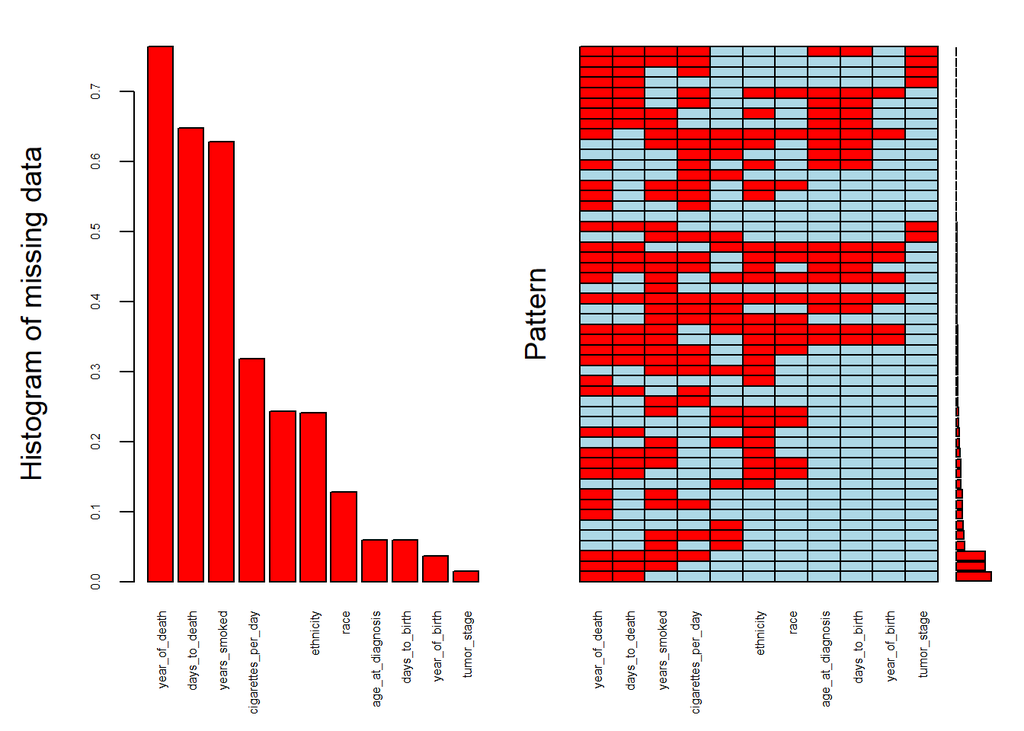

```
##
##  Variables sorted by number of missings:
##                Variable      Count
##           year_of_death 0.76436782
##           days_to_death 0.64750958
##            years_smoked 0.62835249
##      cigarettes_per_day 0.31800766
##  days_to_last_follow_up 0.24329502
##               ethnicity 0.24137931
##                    race 0.12835249
##        age_at_diagnosis 0.05938697
##           days_to_birth 0.05938697
##           year_of_birth 0.03639847
##             tumor_stage 0.01532567
```

```r
#install.packages("VIM")
#(is.(na)) olanları sil plotu öyle çizdir
library(VIM)
aggr(data_w_na, col=c('lightblue','red'),  sortVars=TRUE, labels=names(data_w_na), cex.axis=.5, gap=3, ylab=c("Histogram of missing data","Pattern"))
```

We can see the missing values with descending order in a more visualize version.

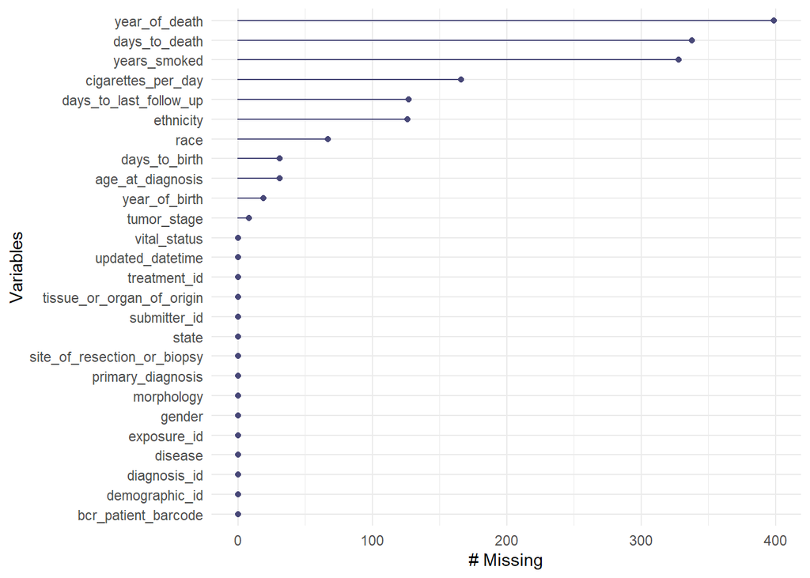

```r
# Which variables contain the most missing variables?
gg_miss_var(data_new)
```

To get a better understanding whether or not the data are missing at random, we are going to visualize the locations of missing values across all variables.

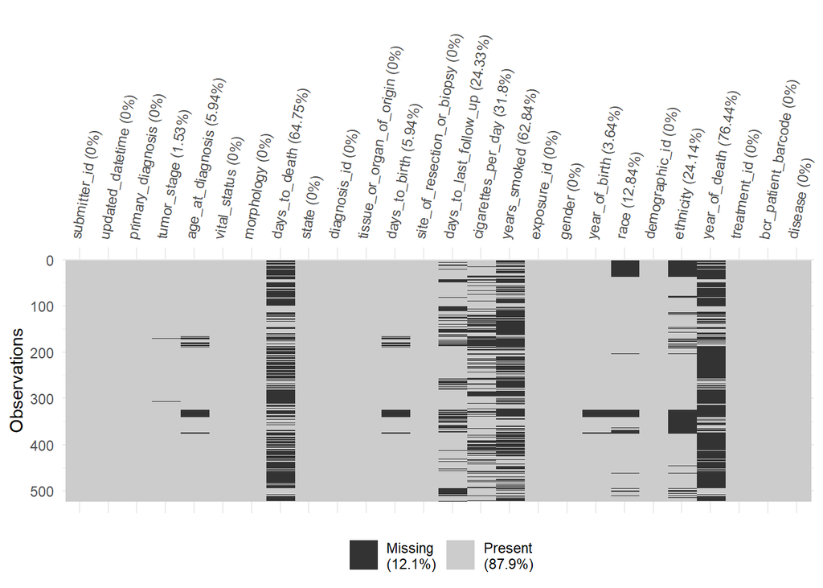

```r
# Where are missings located?
vis_miss(data_new) + theme(axis.text.x = element_text(angle=80))
```

**Note:** We can show the relationship between *days_to_last_follow_up* and *days_to_death* columns** that data is missing with the existence of other.

**There is a direct realtionship between *days_to_last_follow_up* and *days_to_death* columns**  
- In *days_to_death* column values are NaN for **alive** patients and there is just information about **dead** patients how long they lived. - On the other hand, If there is a case like that if patient vital status is dead but days_to_death is 0. We’ll drop that index.

```r
filter(data_new, days_to_death == 0 & vital_status == "dead")
```

```
##   submitter_id                 updated_datetime
## 1 TCGA-05-4395 2018-09-06T21:10:41.393019-05:00
##                    primary_diagnosis tumor_stage age_at_diagnosis vital_status
## 1 Adenocarcinoma with mixed subtypes  stage iiib            27971         dead
##   morphology days_to_death    state                         diagnosis_id
## 1     8255/3             0 released 0d0b1a99-d024-57fb-8517-de831d09934c
##   tissue_or_organ_of_origin days_to_birth site_of_resection_or_biopsy
## 1          Upper lobe, lung        -27971            Upper lobe, lung
##   days_to_last_follow_up cigarettes_per_day years_smoked
## 1                     NA                 NA           NA
##                            exposure_id gender year_of_birth race
## 1 da5b547e-3f4a-55cb-a93b-9ecfb3e3c642   male          1930 <NA>
##                         demographic_id ethnicity year_of_death
## 1 11bc9cf2-76a1-5b47-ab46-934311e2e919      <NA>          2006
##                           treatment_id bcr_patient_barcode disease
## 1 ac6649cc-4792-5bc6-af51-3497178d2645        TCGA-05-4395    LUAD
```

```r
nrow(data_new)
```

```
## [1] 522
```

```r
drop_rows <-subset(data_new, (vital_status=="dead" & days_to_death==0))
nrow(drop_rows)
```

```
## [1] 1
```

```r
data_new <- data_new[!data_new$submitter_id %in% drop_rows$submitter_id,]
filter(data_new, days_to_death == 0 & vital_status == "dead")
```

```
##  [1] submitter_id                updated_datetime
##  [3] primary_diagnosis           tumor_stage
##  [5] age_at_diagnosis            vital_status
##  [7] morphology                  days_to_death
##  [9] state                       diagnosis_id
## [11] tissue_or_organ_of_origin   days_to_birth
## [13] site_of_resection_or_biopsy days_to_last_follow_up
## [15] cigarettes_per_day          years_smoked
## [17] exposure_id                 gender
## [19] year_of_birth               race
## [21] demographic_id              ethnicity
## [23] year_of_death               treatment_id
## [25] bcr_patient_barcode         disease
## <0 rows> (or 0-length row.names)
```

```r
nrow(data_new)
```

```
## [1] 521
```

As we can see we only have one patient with that situation in LUAD and we dropped that patient.

- Now, Now we’ll fill the NaN values in days_to_death column with the days_to_last_follow_up. Subsequently, we’re going to drop the days_to_last_follow_up.

```r
data_new$days_to_death[is.na(data_new$days_to_death)] <- data_new$days_to_last_follow_up[is.na(data_new$days_to_death)]  # Replace NA values

#Drop the days_to_last_follow_up.
data_new <- subset(data_new, select = -c(days_to_last_follow_up))
```

- ’‘’We can drop year_of_birth column because we already have days_to_birth which is more suitable for our algorithm’’’
- ’‘’In ’state’ column all the variables are same for all rows as ‘released’. We’ll drop it’’’ (*SHOW THAT*)
- ’‘’Drop updated_datetime because there is no special information about patient status’’’(We don’t have to prove it with table or plot it’s just not useful)
- ’‘’Also we should remove the ids. Because there is nothing special for these ids. These are just random variables.’’’
  - id_columns = {“diagnosis_id”, “exposure_id”, “demographic_id”, “treatment_id”, “bcr_patient_barcode”}
- 76% of the year_of_death column is missing. We’re going to drop that column because we already have the information of days_to_death which refers to information of lifetime of the patient before dying.

**Note:** We should show that with a nice plot or table.

```r
data_new <- subset(data_new, select = -c(year_of_birth, state, updated_datetime, diagnosis_id, exposure_id, demographic_id, treatment_id, bcr_patient_barcode, year_of_death))
```

## Missing Value Imputations

#### Now we will fill the numeric NaN variables with the mean of columns.

- numeric_columns = {“age_at_diagnosis”, “days_to_birth”,“years_smoked”,“cigarettes_per_day”} **Note:** We can show the missing values with dot plot and after imputing the data we can do the same thing again for all 4 features. **Note:** We can also try to fill the missing values after splitting test and train data and impute the missing values separately for test and train data.

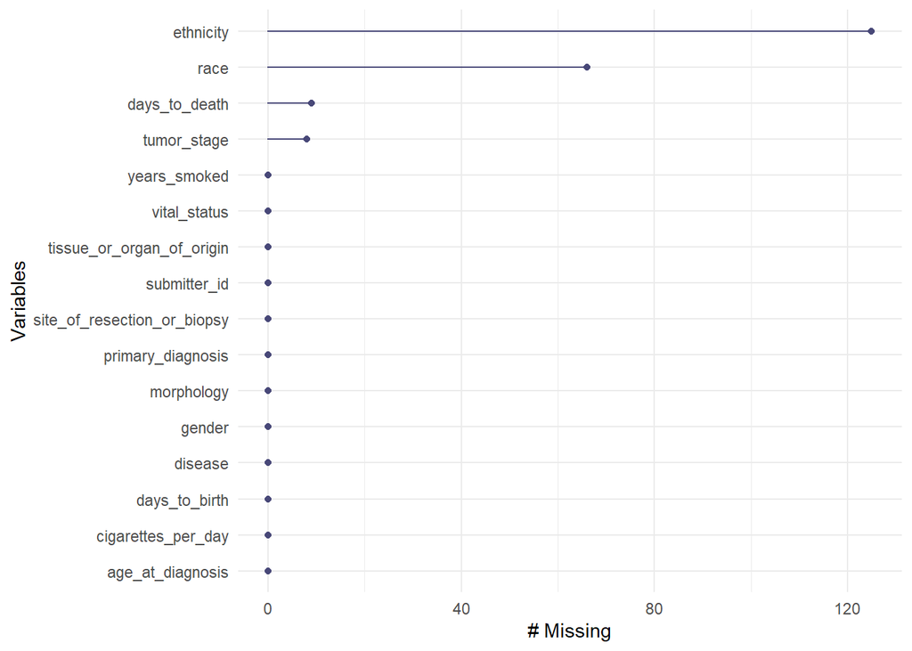

```r
## Try to do the same operation with less code. Try sth fancy.
data_new$age_at_diagnosis[is.na(data_new$age_at_diagnosis)] <- mean(data_new$age_at_diagnosis, na.rm = TRUE)
data_new$days_to_birth[is.na(data_new$days_to_birth)] <- mean(data_new$days_to_birth, na.rm = TRUE)
data_new$years_smoked[is.na(data_new$years_smoked)] <- mean(data_new$years_smoked, na.rm = TRUE)
data_new$cigarettes_per_day[is.na(data_new$cigarettes_per_day)] <- mean(data_new$cigarettes_per_day, na.rm = TRUE)

# Which variables contain the most missing variables?
gg_miss_var(data_new)
```

We can see that we successfully imputed these features with mean of the features.

- ’‘’Now we have null values in **ethnicity** and **race** columns. These columns are highly related with cancer genetic we will keep them as unknown’’’

```r
head(data_new)
```

```
##   submitter_id                  primary_diagnosis tumor_stage age_at_diagnosis
## 1 TCGA-05-4244                Adenocarcinoma, NOS    stage iv            25752
## 2 TCGA-05-4245                Adenocarcinoma, NOS  stage iiia            29647
## 3 TCGA-05-4249                Adenocarcinoma, NOS    stage ib            24532
## 4 TCGA-05-4250                Adenocarcinoma, NOS  stage iiia            29068
## 5 TCGA-05-4382 Adenocarcinoma with mixed subtypes    stage ib            24868
## 6 TCGA-05-4384 Adenocarcinoma with mixed subtypes  stage iiia            24411
##   vital_status morphology days_to_death tissue_or_organ_of_origin days_to_birth
## 1        alive     8140/3             0          Lower lobe, lung        -25752
## 2        alive     8140/3           730          Upper lobe, lung        -29647
## 3        alive     8140/3          1523          Lower lobe, lung        -24532
## 4         dead     8140/3           121          Lower lobe, lung        -29068
## 5        alive     8255/3           607          Upper lobe, lung        -24868
## 6        alive     8255/3           426          Lower lobe, lung        -24411
##   site_of_resection_or_biopsy cigarettes_per_day years_smoked gender race
## 1            Lower lobe, lung           2.082192     31.63402   male <NA>
## 2            Upper lobe, lung           1.753425     31.63402   male <NA>
## 3            Lower lobe, lung           2.849315     31.63402   male <NA>
## 4            Lower lobe, lung           2.575342     31.63402 female <NA>
## 5            Upper lobe, lung           3.397260     31.63402   male <NA>
## 6            Lower lobe, lung           1.095890     24.00000   male <NA>
##   ethnicity disease
## 1      <NA>    LUAD
## 2      <NA>    LUAD
## 3      <NA>    LUAD
## 4      <NA>    LUAD
## 5      <NA>    LUAD
## 6      <NA>    LUAD
```

```r
data_new <- data_new %>%
    mutate(ethnicity = if_else(is.na(ethnicity), "unknown", ethnicity))
data_new <- data_new %>%
    mutate(race = if_else(is.na(race), "unknown", race))

head(data_new)
```

```
##   submitter_id                  primary_diagnosis tumor_stage age_at_diagnosis
## 1 TCGA-05-4244                Adenocarcinoma, NOS    stage iv            25752
## 2 TCGA-05-4245                Adenocarcinoma, NOS  stage iiia            29647
## 3 TCGA-05-4249                Adenocarcinoma, NOS    stage ib            24532
## 4 TCGA-05-4250                Adenocarcinoma, NOS  stage iiia            29068
## 5 TCGA-05-4382 Adenocarcinoma with mixed subtypes    stage ib            24868
## 6 TCGA-05-4384 Adenocarcinoma with mixed subtypes  stage iiia            24411
##   vital_status morphology days_to_death tissue_or_organ_of_origin days_to_birth
## 1        alive     8140/3             0          Lower lobe, lung        -25752
## 2        alive     8140/3           730          Upper lobe, lung        -29647
## 3        alive     8140/3          1523          Lower lobe, lung        -24532
## 4         dead     8140/3           121          Lower lobe, lung        -29068
## 5        alive     8255/3           607          Upper lobe, lung        -24868
## 6        alive     8255/3           426          Lower lobe, lung        -24411
##   site_of_resection_or_biopsy cigarettes_per_day years_smoked gender    race
## 1            Lower lobe, lung           2.082192     31.63402   male unknown
## 2            Upper lobe, lung           1.753425     31.63402   male unknown
## 3            Lower lobe, lung           2.849315     31.63402   male unknown
## 4            Lower lobe, lung           2.575342     31.63402 female unknown
## 5            Upper lobe, lung           3.397260     31.63402   male unknown
## 6            Lower lobe, lung           1.095890     24.00000   male unknown
##   ethnicity disease
## 1   unknown    LUAD
## 2   unknown    LUAD
## 3   unknown    LUAD
## 4   unknown    LUAD
## 5   unknown    LUAD
## 6   unknown    LUAD
```

- We can show the new distribution of the **ethnicity** and **race** columns in a plot.

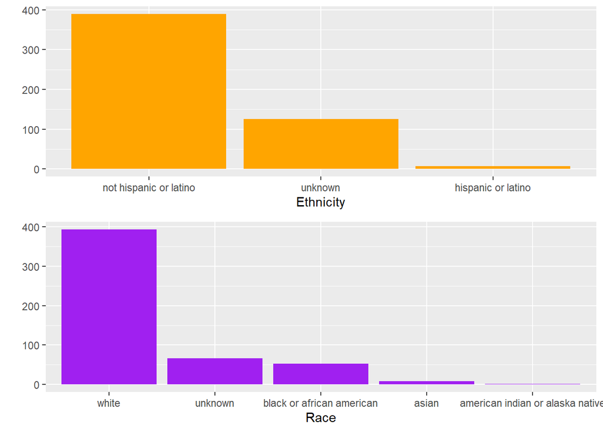

```r
p1 <- ggplot(data_new, aes(x=reorder(ethnicity, ethnicity, function(x)-length(x)))) +
geom_bar(fill='orange') +  labs(x='Ethnicity', y="")
p2 <- ggplot(data_new, aes(x=reorder(race, race, function(x)-length(x)))) +
geom_bar(fill='purple') +  labs(x='Race', y="")

require(gridExtra)
grid.arrange(p1, p2, nrow=2)
```

(#There are still some NaN values in ‘tumor_stage’(8) and ‘days_to_death’(9). We’ll drop them)

```r
sapply(data_new,function(x) sum(is.na(x)))
```

```
##                submitter_id           primary_diagnosis
##                           0                           0
##                 tumor_stage            age_at_diagnosis
##                           8                           0
##                vital_status                  morphology
##                           0                           0
##               days_to_death   tissue_or_organ_of_origin
##                           9                           0
##               days_to_birth site_of_resection_or_biopsy
##                           0                           0
##          cigarettes_per_day                years_smoked
##                           0                           0
##                      gender                        race
##                           0                           0
##                   ethnicity                     disease
##                           0                           0
```

```r
vars <- c("tumor_stage", "days_to_death")
data_new <- data_new %>% drop_na(vars, any_of(vars))
```

```
## Note: Using an external vector in selections is ambiguous.
## i Use `all_of(vars)` instead of `vars` to silence this message.
## i See <https://tidyselect.r-lib.org/reference/faq-external-vector.html>.
```

```r
sapply(data_new,function(x) sum(is.na(x)))
```

```
##                submitter_id           primary_diagnosis
##                           0                           0
##                 tumor_stage            age_at_diagnosis
##                           0                           0
##                vital_status                  morphology
##                           0                           0
##               days_to_death   tissue_or_organ_of_origin
##                           0                           0
##               days_to_birth site_of_resection_or_biopsy
##                           0                           0
##          cigarettes_per_day                years_smoked
##                           0                           0
##                      gender                        race
##                           0                           0
##                   ethnicity                     disease
##                           0                           0
```

As we can see, we don’t have any null values in the dataset anymore.

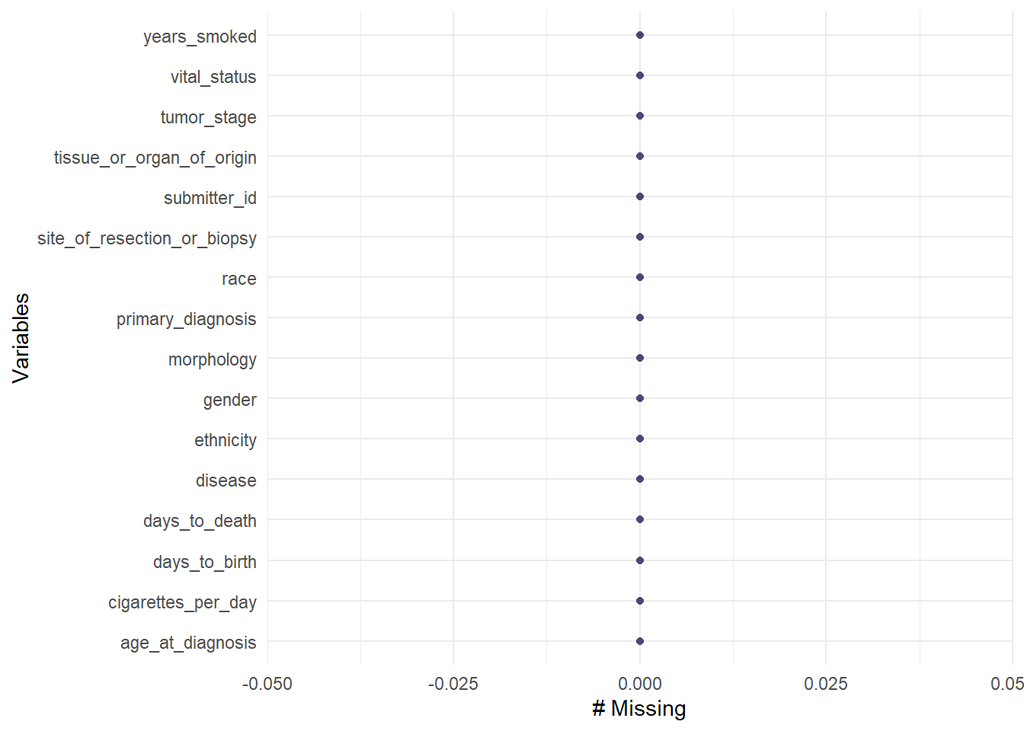

```r
gg_miss_var(data_new)
```

## 211. bloktan devam.

#### It seems that tissue_or_organ_of_origin and site_of_resection_or_biopsy are identical features. We will make sure and if they are identical we’ll drop one of them’’’ (We can improve that part and we can show the identification better.)

```r
ifelse(data_new$tissue_or_organ_of_origin==data_new$site_of_resection_or_biopsy,"Yes","No")
```

```
##   [1] "Yes" "Yes" "Yes" "Yes" "Yes" "Yes" "Yes" "Yes" "Yes" "Yes" "Yes" "Yes"
##  [13] "Yes" "Yes" "Yes" "Yes" "Yes" "Yes" "Yes" "Yes" "Yes" "Yes" "Yes" "Yes"
##  [25] "Yes" "Yes" "Yes" "Yes" "Yes" "Yes" "Yes" "Yes" "Yes" "Yes" "Yes" "Yes"
##  [37] "Yes" "Yes" "Yes" "Yes" "Yes" "Yes" "Yes" "Yes" "Yes" "Yes" "Yes" "Yes"
##  [49] "Yes" "Yes" "Yes" "Yes" "Yes" "Yes" "Yes" "Yes" "Yes" "Yes" "Yes" "Yes"
##  [61] "Yes" "Yes" "Yes" "Yes" "Yes" "Yes" "Yes" "Yes" "Yes" "Yes" "Yes" "Yes"
##  [73] "Yes" "Yes" "Yes" "Yes" "Yes" "Yes" "Yes" "Yes" "Yes" "Yes" "Yes" "Yes"
##  [85] "Yes" "Yes" "Yes" "Yes" "Yes" "Yes" "Yes" "Yes" "Yes" "Yes" "Yes" "Yes"
##  [97] "Yes" "Yes" "Yes" "Yes" "Yes" "Yes" "Yes" "Yes" "Yes" "Yes" "Yes" "Yes"
## [109] "Yes" "Yes" "Yes" "Yes" "Yes" "Yes" "Yes" "Yes" "Yes" "Yes" "Yes" "Yes"
## [121] "Yes" "Yes" "Yes" "Yes" "Yes" "Yes" "Yes" "Yes" "Yes" "Yes" "Yes" "Yes"
## [133] "Yes" "Yes" "Yes" "Yes" "Yes" "Yes" "Yes" "Yes" "Yes" "Yes" "Yes" "Yes"
## [145] "Yes" "Yes" "Yes" "Yes" "Yes" "Yes" "Yes" "Yes" "Yes" "Yes" "Yes" "Yes"
## [157] "Yes" "Yes" "Yes" "Yes" "Yes" "Yes" "Yes" "Yes" "Yes" "Yes" "Yes" "Yes"
## [169] "Yes" "Yes" "Yes" "Yes" "Yes" "Yes" "Yes" "Yes" "Yes" "Yes" "Yes" "Yes"
```

[output cut: 27 more lines]

```r
data_new <- subset(data_new, select = -c(tissue_or_organ_of_origin))
```

## ENCODING

- We’re going to convert our String Binary columns into Numeric Binary columns with LabelEncdoing. But first we’re going to convert these three Character features into Factor.
  - Our Binary String Columns are: vital_status, gender, disease

```r
data_new$vital_status <- as.factor(data_new$vital_status)
data_new$gender <- as.factor(data_new$gender)
data_new$disease <- as.factor(data_new$disease)

head(data_new)
```

```
##   submitter_id                  primary_diagnosis tumor_stage age_at_diagnosis
## 1 TCGA-05-4244                Adenocarcinoma, NOS    stage iv            25752
## 2 TCGA-05-4245                Adenocarcinoma, NOS  stage iiia            29647
## 3 TCGA-05-4249                Adenocarcinoma, NOS    stage ib            24532
## 4 TCGA-05-4250                Adenocarcinoma, NOS  stage iiia            29068
## 5 TCGA-05-4382 Adenocarcinoma with mixed subtypes    stage ib            24868
## 6 TCGA-05-4384 Adenocarcinoma with mixed subtypes  stage iiia            24411
##   vital_status morphology days_to_death days_to_birth
## 1        alive     8140/3             0        -25752
## 2        alive     8140/3           730        -29647
## 3        alive     8140/3          1523        -24532
## 4         dead     8140/3           121        -29068
## 5        alive     8255/3           607        -24868
## 6        alive     8255/3           426        -24411
##   site_of_resection_or_biopsy cigarettes_per_day years_smoked gender    race
## 1            Lower lobe, lung           2.082192     31.63402   male unknown
## 2            Upper lobe, lung           1.753425     31.63402   male unknown
## 3            Lower lobe, lung           2.849315     31.63402   male unknown
## 4            Lower lobe, lung           2.575342     31.63402 female unknown
## 5            Upper lobe, lung           3.397260     31.63402   male unknown
## 6            Lower lobe, lung           1.095890     24.00000   male unknown
##   ethnicity disease
## 1   unknown    LUAD
## 2   unknown    LUAD
## 3   unknown    LUAD
## 4   unknown    LUAD
## 5   unknown    LUAD
## 6   unknown    LUAD
```

```r
label <- LabelEncoder$new()
data_new$vital_status <- label$fit_transform(data_new$vital_status) #0:Alive, 1:Dead
data_new$gender <- label$fit_transform(data_new$gender) #1:Male, 0:Female
data_new$disease <- label$fit_transform(data_new$disease) #We're going to drop it.

head(data_new)
```

```
##   submitter_id                  primary_diagnosis tumor_stage age_at_diagnosis
## 1 TCGA-05-4244                Adenocarcinoma, NOS    stage iv            25752
## 2 TCGA-05-4245                Adenocarcinoma, NOS  stage iiia            29647
## 3 TCGA-05-4249                Adenocarcinoma, NOS    stage ib            24532
## 4 TCGA-05-4250                Adenocarcinoma, NOS  stage iiia            29068
## 5 TCGA-05-4382 Adenocarcinoma with mixed subtypes    stage ib            24868
## 6 TCGA-05-4384 Adenocarcinoma with mixed subtypes  stage iiia            24411
##   vital_status morphology days_to_death days_to_birth
## 1            0     8140/3             0        -25752
## 2            0     8140/3           730        -29647
## 3            0     8140/3          1523        -24532
## 4            1     8140/3           121        -29068
## 5            0     8255/3           607        -24868
## 6            0     8255/3           426        -24411
##   site_of_resection_or_biopsy cigarettes_per_day years_smoked gender    race
## 1            Lower lobe, lung           2.082192     31.63402      1 unknown
## 2            Upper lobe, lung           1.753425     31.63402      1 unknown
## 3            Lower lobe, lung           2.849315     31.63402      1 unknown
## 4            Lower lobe, lung           2.575342     31.63402      0 unknown
## 5            Upper lobe, lung           3.397260     31.63402      1 unknown
## 6            Lower lobe, lung           1.095890     24.00000      1 unknown
##   ethnicity disease
## 1   unknown       0
## 2   unknown       0
## 3   unknown       0
## 4   unknown       0
## 5   unknown       0
## 6   unknown       0
```

- **tumor_stage** is an ordinal column. We’ll encode it manuelly. We can get the unique values for the feature and show them.
  - The order is going to be as follows:
    - tumor_stage_map = {‘stage i’: 1, ‘stage ia’: 2, ‘stage ib’: 3, ‘stage ii’: 4, ‘stage iia’: 5, ‘stage iib’: 6, ‘stage iiia’:7, ‘stage iiib’:8, ‘stage iv’:9 }

```r
head(data_new)
```

```
##   submitter_id                  primary_diagnosis tumor_stage age_at_diagnosis
## 1 TCGA-05-4244                Adenocarcinoma, NOS    stage iv            25752
## 2 TCGA-05-4245                Adenocarcinoma, NOS  stage iiia            29647
## 3 TCGA-05-4249                Adenocarcinoma, NOS    stage ib            24532
## 4 TCGA-05-4250                Adenocarcinoma, NOS  stage iiia            29068
## 5 TCGA-05-4382 Adenocarcinoma with mixed subtypes    stage ib            24868
## 6 TCGA-05-4384 Adenocarcinoma with mixed subtypes  stage iiia            24411
##   vital_status morphology days_to_death days_to_birth
## 1            0     8140/3             0        -25752
## 2            0     8140/3           730        -29647
## 3            0     8140/3          1523        -24532
## 4            1     8140/3           121        -29068
## 5            0     8255/3           607        -24868
## 6            0     8255/3           426        -24411
##   site_of_resection_or_biopsy cigarettes_per_day years_smoked gender    race
## 1            Lower lobe, lung           2.082192     31.63402      1 unknown
## 2            Upper lobe, lung           1.753425     31.63402      1 unknown
## 3            Lower lobe, lung           2.849315     31.63402      1 unknown
## 4            Lower lobe, lung           2.575342     31.63402      0 unknown
## 5            Upper lobe, lung           3.397260     31.63402      1 unknown
## 6            Lower lobe, lung           1.095890     24.00000      1 unknown
##   ethnicity disease
## 1   unknown       0
## 2   unknown       0
## 3   unknown       0
## 4   unknown       0
## 5   unknown       0
## 6   unknown       0
```

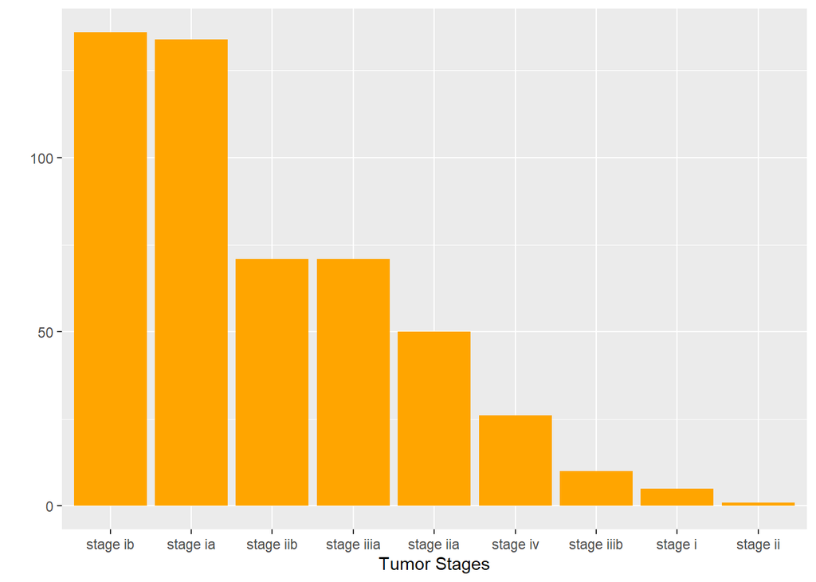

```r
p1 <- ggplot(data_new, aes(x=reorder(tumor_stage, tumor_stage, function(x)-length(x)))) +
geom_bar(fill='orange') +  labs(x='Tumor Stages', y="")
p1
```

```r
data_new$tumor_stage <- as.numeric(as.factor(data_new$tumor_stage))


str(data_new$tumor_stage)
```

```
##  num [1:504] 9 7 3 7 3 7 2 3 8 6 ...
```

```r
typeof(data_new$tumor_stage)
```

```
## [1] "double"
```

```r
head(data_new)
```

```
##   submitter_id                  primary_diagnosis tumor_stage age_at_diagnosis
## 1 TCGA-05-4244                Adenocarcinoma, NOS           9            25752
## 2 TCGA-05-4245                Adenocarcinoma, NOS           7            29647
## 3 TCGA-05-4249                Adenocarcinoma, NOS           3            24532
## 4 TCGA-05-4250                Adenocarcinoma, NOS           7            29068
## 5 TCGA-05-4382 Adenocarcinoma with mixed subtypes           3            24868
## 6 TCGA-05-4384 Adenocarcinoma with mixed subtypes           7            24411
##   vital_status morphology days_to_death days_to_birth
## 1            0     8140/3             0        -25752
## 2            0     8140/3           730        -29647
## 3            0     8140/3          1523        -24532
## 4            1     8140/3           121        -29068
## 5            0     8255/3           607        -24868
## 6            0     8255/3           426        -24411
##   site_of_resection_or_biopsy cigarettes_per_day years_smoked gender    race
## 1            Lower lobe, lung           2.082192     31.63402      1 unknown
## 2            Upper lobe, lung           1.753425     31.63402      1 unknown
## 3            Lower lobe, lung           2.849315     31.63402      1 unknown
## 4            Lower lobe, lung           2.575342     31.63402      0 unknown
## 5            Upper lobe, lung           3.397260     31.63402      1 unknown
## 6            Lower lobe, lung           1.095890     24.00000      1 unknown
##   ethnicity disease
## 1   unknown       0
## 2   unknown       0
## 3   unknown       0
## 4   unknown       0
## 5   unknown       0
## 6   unknown       0
```

- We’ll apply OneHotEncoding for Nominal Columns with **dummyVars** function in the *caret* package.
  - Our categorical columns are: **primary_diagnosis, morphology, site_of_resection_or_biopsy, race, ethnicity**

```r
categorical.cols <- subset(data_new, select=c(primary_diagnosis, morphology, site_of_resection_or_biopsy, race, ethnicity))
head(categorical.cols)
```

```
##                    primary_diagnosis morphology site_of_resection_or_biopsy
## 1                Adenocarcinoma, NOS     8140/3            Lower lobe, lung
## 2                Adenocarcinoma, NOS     8140/3            Upper lobe, lung
## 3                Adenocarcinoma, NOS     8140/3            Lower lobe, lung
## 4                Adenocarcinoma, NOS     8140/3            Lower lobe, lung
## 5 Adenocarcinoma with mixed subtypes     8255/3            Upper lobe, lung
## 6 Adenocarcinoma with mixed subtypes     8255/3            Lower lobe, lung
##      race ethnicity
## 1 unknown   unknown
## 2 unknown   unknown
## 3 unknown   unknown
## 4 unknown   unknown
## 5 unknown   unknown
## 6 unknown   unknown
```

```r
dmy <- dummyVars(" ~ .", data = categorical.cols)
categorical.cols <- data.frame(predict(dmy, newdata = categorical.cols))
head(categorical.cols)
```

```
##   primary_diagnosisAcinar.cell.carcinoma
## 1                                      0
## 2                                      0
## 3                                      0
## 4                                      0
## 5                                      0
## 6                                      0
##   primary_diagnosisAdenocarcinoma.with.mixed.subtypes
## 1                                                   0
## 2                                                   0
## 3                                                   0
## 4                                                   0
## 5                                                   1
## 6                                                   1
##   primary_diagnosisAdenocarcinoma..NOS
```

[output cut: 139 more lines]

- We’ll drop categorical columns and then we’ll merge the new One Hot Encoded version of categrical.cols to the dataset.

```r
categorical.cols$submitter_id <- data_new$submitter_id #We need that submitter_id column to merge two dataframes.
data_new <- subset(data_new, select = -c(primary_diagnosis, morphology, site_of_resection_or_biopsy, race, ethnicity))
data_new <- merge(data_new, categorical.cols, by="submitter_id")
```

- Drop vital_status(alive or dead) and disease. In real life we don’t need vital_status feature. On the other hand **disease** stands for type of Lung Cancer(LUAD or LUSC) in our case all the patients are LUAD cancer, therefore we don’t need to keep that column. Also we do not need **submitter_id** feature any more.

```r
data_new <- subset(data_new, select = -c(vital_status, disease, submitter_id))
```

## Classifiyng Algorithm

We would like to classify the patients such as they will live more than five years or not according to their **days_to_death** feature. Therefore, if the patient’s remaining life more than 5 years we assumed the patient will live long(assign 1), otherwise short(assign 0). Then convert it to the factor.

```r
head(data_new)
```

```
##   tumor_stage age_at_diagnosis days_to_death days_to_birth cigarettes_per_day
## 1           9            25752             0        -25752           2.082192
## 2           7            29647           730        -29647           1.753425
## 3           3            24532          1523        -24532           2.849315
## 4           7            29068           121        -29068           2.575342
## 5           3            24868           607        -24868           3.397260
## 6           7            24411           426        -24411           1.095890
##   years_smoked gender primary_diagnosisAcinar.cell.carcinoma
## 1     31.63402      1                                      0
## 2     31.63402      1                                      0
## 3     31.63402      1                                      0
## 4     31.63402      0                                      0
## 5     31.63402      1                                      0
## 6     24.00000      1                                      0
##   primary_diagnosisAdenocarcinoma.with.mixed.subtypes
```

[output cut: 146 more lines]

```r
data_new$days_to_death <- ifelse(data_new$days_to_death>1825, 1, 0)
data_new$days_to_death <- as.factor(data_new$days_to_death)
head(data_new)
```

```
##   tumor_stage age_at_diagnosis days_to_death days_to_birth cigarettes_per_day
## 1           9            25752             0        -25752           2.082192
## 2           7            29647             0        -29647           1.753425
## 3           3            24532             0        -24532           2.849315
## 4           7            29068             0        -29068           2.575342
## 5           3            24868             0        -24868           3.397260
## 6           7            24411             0        -24411           1.095890
##   years_smoked gender primary_diagnosisAcinar.cell.carcinoma
## 1     31.63402      1                                      0
## 2     31.63402      1                                      0
## 3     31.63402      1                                      0
## 4     31.63402      0                                      0
## 5     31.63402      1                                      0
## 6     24.00000      1                                      0
##   primary_diagnosisAdenocarcinoma.with.mixed.subtypes
```

[output cut: 146 more lines]

```r
str(data_new)
```

```
## 'data.frame':    504 obs. of  45 variables:
##  $ tumor_stage                                                 : num  9 7 3 7 3 7 2 3 8 6 ...
##  $ age_at_diagnosis                                            : num  25752 29647 24532 29068 24868 ...
##  $ days_to_death                                               : Factor w/ 2 levels "0","1": 1 1 1 1 1 1 1 1 1 1 ...
##  $ days_to_birth                                               : num  -25752 -29647 -24532 -29068 -24868 ...
##  $ cigarettes_per_day                                          : num  2.08 1.75 2.85 2.58 3.4 ...
##  $ years_smoked                                                : num  31.6 31.6 31.6 31.6 31.6 ...
##  $ gender                                                      : num  1 1 1 0 1 1 1 0 1 1 ...
##  $ primary_diagnosisAcinar.cell.carcinoma                      : num  0 0 0 0 0 0 0 0 0 0 ...
##  $ primary_diagnosisAdenocarcinoma.with.mixed.subtypes         : num  0 0 0 0 1 1 1 1 1 1 ...
##  $ primary_diagnosisAdenocarcinoma..NOS                        : num  1 1 1 1 0 0 0 0 0 0 ...
##  $ primary_diagnosisBronchio.alveolar.carcinoma..mucinous      : num  0 0 0 0 0 0 0 0 0 0 ...
##  $ primary_diagnosisBronchiolo.alveolar.adenocarcinoma..NOS    : num  0 0 0 0 0 0 0 0 0 0 ...
##  $ primary_diagnosisBronchiolo.alveolar.carcinoma..non.mucinous: num  0 0 0 0 0 0 0 0 0 0 ...
##  $ primary_diagnosisClear.cell.adenocarcinoma..NOS             : num  0 0 0 0 0 0 0 0 0 0 ...
```

[output cut: 31 more lines]

## Let’s see if we have a balanced classes or not.

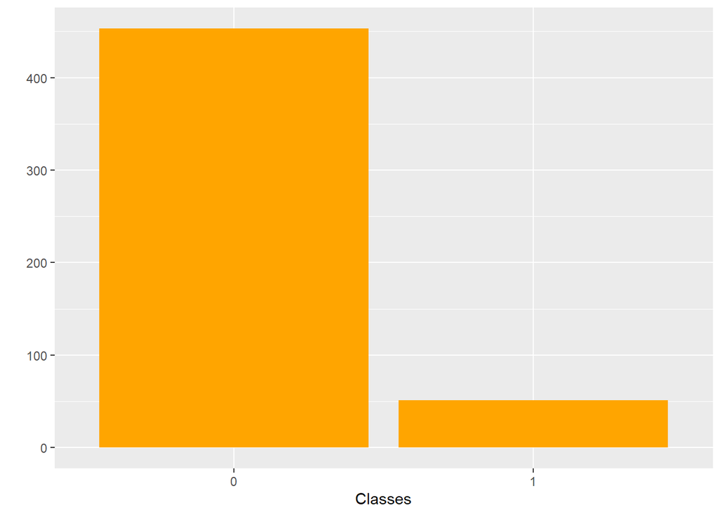

```r
p1 <- ggplot(data_new, aes(x=reorder(days_to_death, days_to_death, function(x)-length(x)))) +
geom_bar(fill='orange') +  labs(x='Classes', y="")
p1
```

It seems that we have a serious imbalance class classification problem.

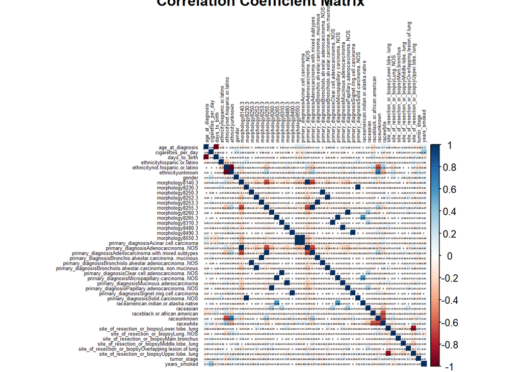

```r
library(caret)
matrix <- data_new %>%
    select_if(is.numeric) %>%
    cor(.)
corrplot(matrix, method = "color", addCoef.col="black", order = "alphabet", number.cex=0.2, title = "Correlation Coefficient Matrix",
         tl.cex=0.4, tl.col = "black")
```